# GERCOL_Ceosens_RM

[figure not shown]

```python
from IPython.display import Image
Image("Colegios-Zaragoza.png")
```

## Carga de librerías

```python
import psycopg2
import pandas as pd
import pandas.io.sql as sqlio
import numpy as np
from matplotlib import pyplot as plt
from datetime import date
import seaborn as sns
```

## Conexión a la base de datos

Una vez cargadas las librerías, se procede a extraer el dataframe de la base de datos ceosens. Dicha base de datos está ubicada den una PostgreSQL a la cual se puede acceder desde python definiendo sus credenciales específicos. Los datos que se cargarán en este script serán el dataframe utilidado durante el estudio. Es por ello por lo que, más adelante, se procederá a incluir los datos obtenidos de fuentes públicas (Ayuntamiento de Zaragoza) a este dataset, dado que van a ser asímismo objeto de estudio.

```python
conn = psycopg2.connect(host="frischluft.westeurope.cloudapp.azure.com",
                        port = 5432,
                        database="ceosens",
                        user="harut",
                        password="176a04923cebac56040a")

cur = conn.cursor()
```

```python
sql = '''
select temperature, humidity, co2, pm25, covid19, "Date",c."MAC",b."h_temp",b."ID"
from ceosens c
left join
    (WITH borrar as
        (select *, ROW_NUMBER()
         OVER(PARTITION BY "MAC" ORDER BY id) AS row_num, ROW_NUMBER ()
         OVER (ORDER BY NULL) AS "ID"
         from ubicaciones
         where id like 'MICA%')
    SELECT  "ID", ubicacion, "MAC", h_temp
    from borrar
    WHERE row_num>1
    order BY "ID") b
on  c."MAC" = b."MAC";
'''

dataset = sqlio.read_sql_query(sql, conn)
```

```python
dataset = (dataset.assign(Date= lambda x: pd.to_datetime(x["Date"]).dt.strftime('%Y-%m-%d %H'))
                  .dropna(axis=1, how= 'all')
                  .groupby(['Date', 'MAC','ID','h_temp']).agg({'temperature':'mean','humidity':'mean',
                                                               'co2':'mean','pm25':'mean','covid19':'mean'})
                  .dropna(how= 'any')
                  .assign(temperature = lambda x: round(x["temperature"], 2),
                          humidity = lambda x: round(x["humidity"], 2),
                          co2 = lambda x: round(x["co2"], 2)))
```

```python
df = (pd.read_excel(r"C:\\Users\\ArantxaOteiza\\Desktop\\Datos públicos.xlsx", engine= "openpyxl")
        .rename(columns={"AÑO": "year", "MES": "month", "DIA": "day", "HOUR": "hour"})
        .assign(minute = 0,
                second = 0,
                Date = lambda x: pd.to_datetime(x[["year", "month", "day", "hour", "minute", "second"]]).dt.strftime('%Y-%m-%d %H')))
```

```python
final = (pd.merge(dataset.reset_index(),
                  df[["Date", "REAL_TEMP"]],
                  on= "Date", how= "left")
           .set_index(["Date",  "MAC", "ID"]))
```

```python
# El dataset final es exactamente igual que el proporcionado, con la diferencia de que la columna REAL_TEMP
# ha sido introducida en el multi-índice.
final
```

[output not shown]

Representación estadística de las variables de medición que se integran en la base de datos ceosens:

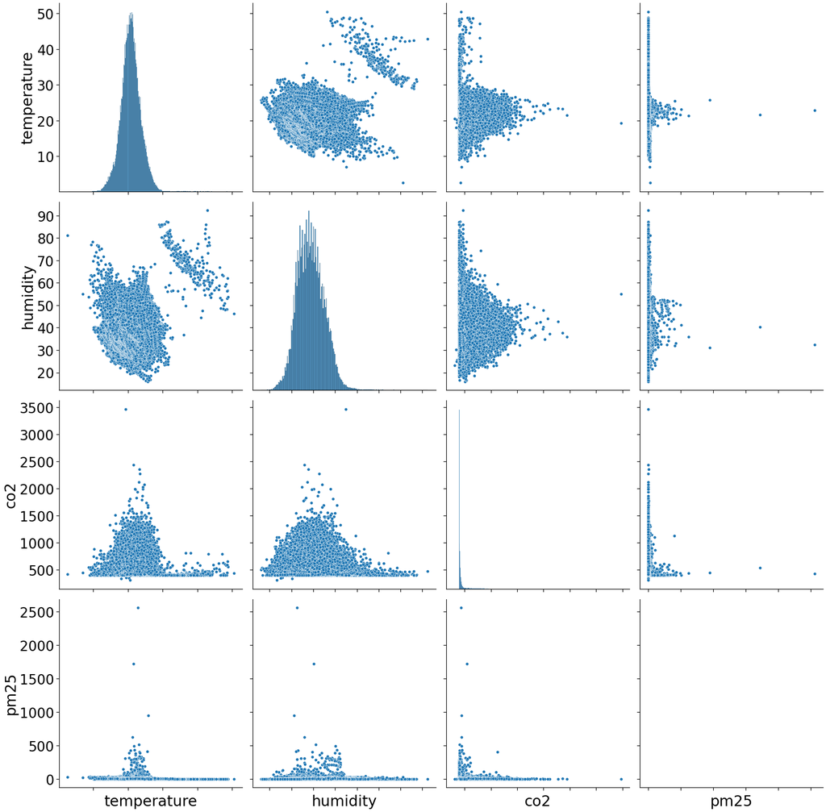

```python
with sns.plotting_context("notebook",font_scale=2.5):
    g = sns.pairplot(dataset[['temperature','humidity','co2','pm25']],
                  palette='tab20',size=6)
g.set(xticklabels=[]);
```

## Regresión lineal múltiple

Una vez preprocesados los datos y visto un primer análisis estadístico básico, se procede a realizar una regresión lineal múltiple. La elección de este modelo de regresión viene de que lo que se pretende es extraer una predicción de la temperatura real de las aulas en función de su nivel de estrés térmico y la temperatura exterior.

Los datos de la temperatura exterior pudieron ser extraídos gracias a facilitación de datos meteorológicos del Ayuntamiento de Zaragoza.

Se intuye que si las predicciones se acercan a los valores reales, es decir, si el modelo es bueno, estará estrechamente relacionado el nivel de estrés térmico en las aulas con la temperatura que finalmente hace en el aula. De esta manera, se podrán tomar medidas de regulación térmica en las clases que tengan niveles de estrés térmico altos.

```python
df= final[['h_temp', 'REAL_TEMP','temperature']]
df=df.dropna()
```

```python
X = df.iloc[:, :-1].values
Y = df.iloc[:, 2].values
X
```

```
array([[ 1. ,  3. ],
       [ 1. ,  3. ],
       [ 2. ,  3. ],
       ...,
       [ 2. , 27.8],
       [ 0. , 27.8],
       [ 1. , 27.8]])
```

```python
# datos categóricos

from sklearn.model_selection import train_test_split
X_train, X_test, y_train, y_test = train_test_split(X, Y, test_size = 0.2, random_state = 0)


from sklearn.linear_model import LinearRegression
regression = LinearRegression()
regression.fit(X_train, y_train)


y_pred = regression.predict(X_test)
```

```python
list_of_tuples = list(zip(y_test, y_pred))
dfA = pd.DataFrame(list_of_tuples,
                  columns = ['X_test', 'y_pred'])

dfA
```

|  | X_test | y_pred |
| --- | --- | --- |
| 0 | 15.84 | 20.453732 |
| 1 | 26.23 | 25.004547 |
| 2 | 21.07 | 20.744209 |
| 3 | 26.34 | 25.017935 |
| 4 | 24.66 | 21.629030 |
| ... | ... | ... |
| 21412 | 19.79 | 22.694114 |
| 21413 | 20.06 | 21.131513 |
| 21414 | 12.61 | 16.658637 |
| 21415 | 19.34 | 20.370294 |
| 21416 | 19.83 | 21.647917 |

21417 rows × 2 columns

```python
print(regression.coef_)
```

```
[1.08397143 0.32275283]
```

[figure not shown]

```python
######################################## Data preparation #########################################

df= final[['h_temp', 'REAL_TEMP','temperature']]
df=df.dropna()

X =   df['REAL_TEMP'].values.reshape(-1,1)
y = df['temperature'].values

################################################ Train #############################################

ols = LinearRegression()
model = ols.fit(X, y)
response = model.predict(X)

############################################## Evaluate ############################################

r2 = model.score(X, y)

############################################## Plot ################################################

plt.style.use('default')
plt.style.use('ggplot')

fig, ax = plt.subplots(figsize=(8, 4))

ax.plot(X, response, color='k', label='Regression model')
ax.scatter(X, y, edgecolor='k', facecolor='white', alpha=0.7, label='Sample data')
ax.set_ylabel('Temperatura en aulas', fontsize=14)
ax.set_xlabel('Temperatura real', fontsize=14)
ax.text(0.8, 0.1, 'aegis4048.github.io', fontsize=13, ha='center', va='center',
         transform=ax.transAxes, color='white', alpha=0.5)
ax.legend(facecolor='white', fontsize=11)
ax.set_title('Regresión lineal múltiple' , fontsize=18)

fig.tight_layout()
```